# EXPLORING NETFLIX

## Spring 2024 Data Science Project

### by Ishaan Gupta, Tejas Mutneja, Agastya Mukherjee, Mahendra Kumar

Member 1: Agastya Mukherjee Contribution: 100% Member 2: Tejas Mutneja Contribution: 100% Member 3: Mahendra Kumar Contribution: 100% Member 4: Ishaan Gupta Contribution: 100%

"We, all team members, agree together that the above information is true, and we are confident about our contributions to this submitted project/final tutorial." Agastya Mukherjee 05/07/2024 Tejas Mutneja 05/07/2024 Mahendra Kumar 05/07/2024 Ishaan Gupta 05/07/2024

### (I) INTRODUCTION

Analysis of Netflix Titles: Trends and Insights

Understanding these aspects is crucial as it provides insights into Netflix's content strategy, revealing how it adapts to cultural shifts and consumer preferences. This analysis not only benefits media analysts and enthusiasts looking to grasp the dynamics of content distribution but also assists producers and directors in making informed decisions about potential gaps and opportunities in the streaming landscape.

### (II) Data curation

#### Dataset Source:

This analysis is based on the netflix_titles.csv dataset, which includes comprehensive details on shows and movies available on Netflix as of the last update. This dataset is publicly available and can be found on platforms like Kaggle, which hosts various open-source datasets. For the purpose of this project, the dataset is assumed to be up-to-date as of 2024.

link to the dataset : https://www.kaggle.com/datasets/shivamb/netflix-shows

#### Dataset Description:

The dataset consists of the following columns:

show_id: A unique identifier for each title.

type: The type of title (e.g., Movie or TV Show).

title: The title of the show or movie.

director: The director(s) of the title.

cast: The main cast involved in the film or series.

country: The country where the title was produced.

date_added: The date on which the title was added to Netflix.

release_year: The official release year of the title.

rating: The age/advisory rating of the title.

duration: The length of the title, either in minutes (for movies) or seasons (for TV shows).

listed_in: The genres under which the title is listed.

description: A brief description of the title.

Data Preparation To ensure our analysis is conducted efficiently, we'll perform initial data cleaning steps to handle missing values and parse relevant columns for better accessibility and analysis. Below is the Python code using Pandas to prepare this dataset:

```python
import pandas as pd

netflix_data = pd.read_csv('netflix_titles.csv')

print(netflix_data.head())

# we will check the null count here
print(netflix_data.isnull().sum())
```

```
  show_id     type                  title         director  \
0      s1    Movie   Dick Johnson Is Dead  Kirsten Johnson
1      s2  TV Show          Blood & Water              NaN
2      s3  TV Show              Ganglands  Julien Leclercq
3      s4  TV Show  Jailbirds New Orleans              NaN
4      s5  TV Show           Kota Factory              NaN

                                                cast        country  \
0                                                NaN  United States
1  Ama Qamata, Khosi Ngema, Gail Mabalane, Thaban...   South Africa
2  Sami Bouajila, Tracy Gotoas, Samuel Jouy, Nabi...            NaN
3                                                NaN            NaN
4  Mayur More, Jitendra Kumar, Ranjan Raj, Alam K...          India

           date_added  release_year rating   duration  \
0  September 25, 2021          2020  PG-13     90 min
1  September 24, 2021          2021  TV-MA  2 Seasons
2  September 24, 2021          2021  TV-MA   1 Season
3  September 24, 2021          2021  TV-MA   1 Season
4  September 24, 2021          2021  TV-MA  2 Seasons

                                           listed_in  \
0                                      Documentaries
1    International TV Shows, TV Dramas, TV Mysteries
2  Crime TV Shows, International TV Shows, TV Act...
3                             Docuseries, Reality TV
4  International TV Shows, Romantic TV Shows, TV ...

                                         description
0  As her father nears the end of his life, filmm...
1  After crossing paths at a party, a Cape Town t...
2  To protect his family from a powerful drug lor...
3  Feuds, flirtations and toilet talk go down amo...
4  In a city of coaching centers known to train I...
show_id            0
type               0
title              0
director        2634
cast             825
country          831
date_added        10
release_year       0
rating             4
duration           3
listed_in          0
description        0
dtype: int64
```

After seeing the data we can see that we have a lot of missing values. For the rating, duration and date added where the number of missing values is less than equal to 10. We can simply drop those.

```python
# We will be dropping rows with missing values in specific columns
netflix_data.dropna(subset=['rating', 'duration', 'date_added'], inplace=True)
# Checking for missing values
missing_values = netflix_data.isnull().sum()
print(missing_values)
```

```
show_id            0
type               0
title              0
director        2621
cast             825
country          829
date_added         0
release_year       0
rating             0
duration           0
listed_in          0
description        0
dtype: int64
```

Now, We want to see if the column of director is important or not. We will groupby director to see the relevance.

```python
# We Group the data by director
grouped_director = netflix_data.groupby('director')
director_counts = grouped_director.size()
print(director_counts)

# Find the director with the maximum count
max_movies_director = director_counts.idxmax()
max_movies_count = director_counts.max()
print("Director with the most movies:", max_movies_director)
print("Number of movies directed:", max_movies_count)
```

```
director
A. L. Vijay            2
A. Raajdheep           1
A. Salaam              1
A.R. Murugadoss        2
Aadish Keluskar        1
                      ..
Çagan Irmak            1
Ísold Uggadóttir       1
Óskar Thór Axelsson    1
Ömer Faruk Sorak       2
Şenol Sönmez           2
Length: 4526, dtype: int64
Director with the most movies: Rajiv Chilaka
Number of movies directed: 19
```

1. significant portion of the 'director' column consists of null values, it may not provide meaningful information for analysis. In such cases, imputing or filling missing values may introduce bias or inaccuracies in the data.
2. The 'director' column contains a large number of unique values (4526 in this case). High cardinality can make it challenging to analyze or derive meaningful insights from this feature.
3. factors such as genre, release year, or cast may have a more substantial influence on the characteristics or performance of a movie.

Conclusion: Dropping this factor could streamline our analysis , improve the quality and insights of our data. So we can drop the column of director. Our analysis would focus on data such as genre, release year, or ratings.

```python
# Drop the 'director' column from the DataFrame
netflix_data.drop(columns=['director'], inplace=True)

print(netflix_data.head())
```

```
  show_id     type                  title  \
0      s1    Movie   Dick Johnson Is Dead
1      s2  TV Show          Blood & Water
2      s3  TV Show              Ganglands
3      s4  TV Show  Jailbirds New Orleans
4      s5  TV Show           Kota Factory

                                                cast        country  \
0                                                NaN  United States
1  Ama Qamata, Khosi Ngema, Gail Mabalane, Thaban...   South Africa
2  Sami Bouajila, Tracy Gotoas, Samuel Jouy, Nabi...            NaN
3                                                NaN            NaN
4  Mayur More, Jitendra Kumar, Ranjan Raj, Alam K...          India

           date_added  release_year rating   duration  \
```

[output cut: 19 more lines]

Now we have to deal with missing values for cast and country columns. Since we are going to mainly focus on rating, type, date_added, release_year and duration columns, we are replacing missing values by 'Unknown' i.e. we don't care about cast and country.

```python
# Fill missing values for 'country' and 'director' with 'Unknown'
netflix_data['country'].fillna('Unknown', inplace=True)
netflix_data['cast'].fillna('Unknown', inplace=True)
# Check for missing values
missing_values = netflix_data.isnull().sum()
print(missing_values)
```

```
show_id         0
type            0
title           0
cast            0
country         0
date_added      0
release_year    0
rating          0
duration        0
listed_in       0
description     0
dtype: int64
```

Now that we don't have any missing values, we can have a standard date format for data_added column.

```python
netflix_data['date_added'] = pd.to_datetime(netflix_data['date_added'], errors='coerce')

print(netflix_data.head())
```

```
  show_id     type                  title  \
0      s1    Movie   Dick Johnson Is Dead
1      s2  TV Show          Blood & Water
2      s3  TV Show              Ganglands
3      s4  TV Show  Jailbirds New Orleans
4      s5  TV Show           Kota Factory

                                                cast        country  \
0                                            Unknown  United States
1  Ama Qamata, Khosi Ngema, Gail Mabalane, Thaban...   South Africa
2  Sami Bouajila, Tracy Gotoas, Samuel Jouy, Nabi...        Unknown
3                                            Unknown        Unknown
4  Mayur More, Jitendra Kumar, Ranjan Raj, Alam K...          India

  date_added  release_year rating   duration  \
```

[output cut: 19 more lines]

### (III) Exploratory Data Analysis

Let's first analyze the proportion of movies to TV shows to understand Netflix's content strategy

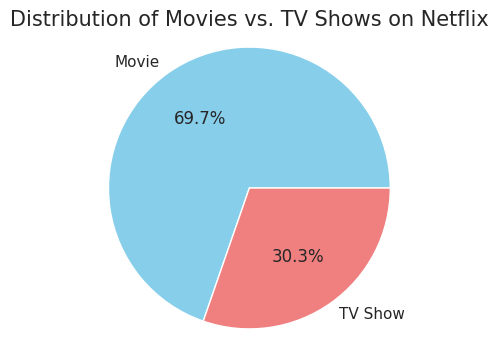

```python
import matplotlib.pyplot as plt
import seaborn as sns

sns.set(style="whitegrid")

# Analysis 1: Distribution of Movies vs. TV Shows
type_counts = netflix_data['type'].value_counts()


plt.figure(figsize=(4, 4))
plt.pie(type_counts, labels=type_counts.index, autopct='%1.1f%%', colors=['skyblue', 'lightcoral'])
plt.title('Distribution of Movies vs. TV Shows on Netflix', fontsize=15)
plt.axis('equal')
plt.show()
```

This plot visualizes the distribution of Movies vs. TV Shows on Netflix, highlighting Netflix's content strategy. From this analysis, we can conclude that Netflix has a higher number of movies compared to TV shows in its catalog. This could indicate a strategic focus on movies, potentially due to consumer preferences or content acquisition strategies.

**First Anaysis and Hypothesis** - distribution of release years to observe trends in content production or acquisition over time. This will involve examining the release_year feature and visualizing the data to identify any notable patterns.

T-test for Average Release Year of Movies vs. TV Shows: To test if there's a significant difference in the average release year of movies compared to TV shows, indicating a trend in content acquisition or production.

H 0  : The average release year for movies is equal to the average release year for TV shows.

H A  : The average release year for movies is not equal to the average release year for TV shows.

```python
# Using T-test
from scipy.stats import ttest_ind

import pandas as pd

df = pd.read_csv('netflix_titles.csv')

# Filter the dataset for movies and TV shows and their release years
movies_release_years = df[df['type'] == 'Movie']['release_year']
tv_shows_release_years = df[df['type'] == 'TV Show']['release_year']

# Perform T-test
t_stat, p_val = ttest_ind(movies_release_years, tv_shows_release_years)

t_stat, p_val
```

```
(-17.339416624102576, 2.9659411360902904e-66)
```

The T-test comparing the average release year of movies to TV shows yields a t-statistic of approximately -17.34 and a p-value of 2.97 × 10−66. This highly significant p-value indicates that we should reject the null hypothesis (H0) that the average release year for movies is equal to the average release year for TV shows. Therefore, we accept the alternative hypothesis (HA) that there is a significant difference in the average release year between movies and TV shows on Netflix, suggesting differing trends in content acquisition or production.

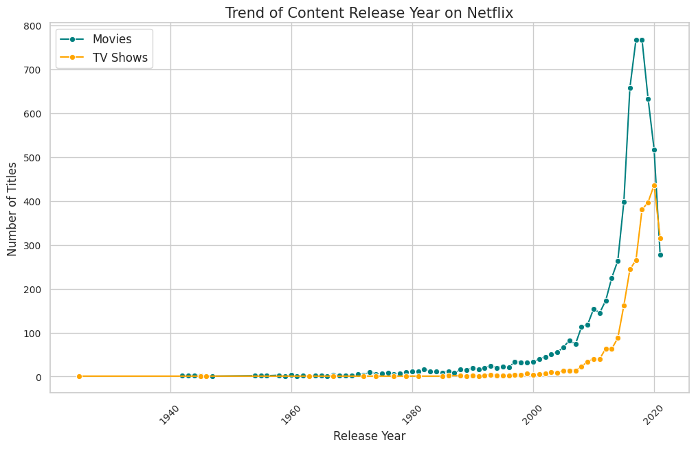

```python
import matplotlib.pyplot as plt
import seaborn as sns

# Separate DataFrame for movies and TV shows
movies_df = df[df['type'] == 'Movie']
tv_shows_df = df[df['type'] == 'TV Show']

# Count the number of movies and TV shows released each year
movies_counts = movies_df['release_year'].value_counts().sort_index()
tv_shows_counts = tv_shows_df['release_year'].value_counts().sort_index()


plt.figure(figsize=(12, 7))
sns.lineplot(x=movies_counts.index, y=movies_counts.values, marker="o", color="teal", label='Movies')
sns.lineplot(x=tv_shows_counts.index, y=tv_shows_counts.values, marker="o", color="orange", label='TV Shows')
plt.title('Trend of Content Release Year on Netflix', fontsize=15)
plt.xlabel('Release Year', fontsize=12)
plt.ylabel('Number of Titles', fontsize=12)
plt.xticks(rotation=45, fontsize=10)
plt.yticks(fontsize=10)
plt.grid(True)
plt.legend(fontsize=12)
plt.show()
```

The above plot illustrates the trend of content release years on Netflix, showing the number of titles added to the catalog over time. We observe a significant increase in the number of titles, especially in recent years. This trend suggests that Netflix has been actively expanding its content library, possibly due to the growing demand for streaming services and the need to offer a diverse range of titles to attract and retain subscribers. We can also see that the peak for each type was different, it was earlier for movies compared to TV shows probably due to recent increase in demand for TV shows in the late 2000s. It could also be possible due to covid-19 and people having much more time to binge shows than before.

**SECOND ANALYSIS AND HYPOTHESIS** - distribution of content ratings to understand the target audience demographics better. This analysis will help us identify which age groups are primarily targeted by Netflix's content.

Chi-Square Test for Independence between Rating and Type (Movie/TV Show): To check if there's an association between the type of content (movie or TV show) and its content rating.

H 0  : There is no association between content type and content rating (they are independent).

H A  : There is an association between content type and content rating (they are not independent

```python
from scipy.stats import chi2_contingency

# Creating a contingency table of type and rating
contingency_table = pd.crosstab(df['type'], df['rating'])

# Performing Chi-Square Test
chi2, p, dof, expected = chi2_contingency(contingency_table)

chi2, p
```

```
(1047.6941440561634, 6.822436324208583e-213)
```

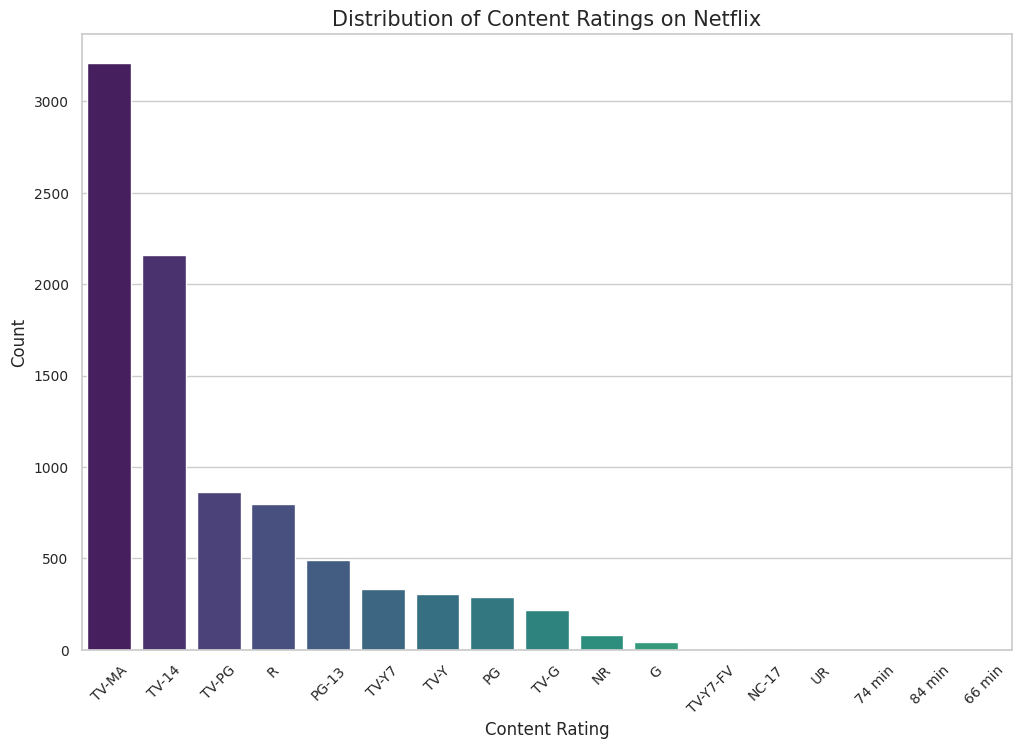

```python
# Analysis: Content Rating Distribution
rating_counts = df['rating'].value_counts()

# Plotting
plt.figure(figsize=(12, 8))
sns.barplot(x=rating_counts.index, y=rating_counts.values, palette="viridis")
plt.title('Distribution of Content Ratings on Netflix', fontsize=15)
plt.xlabel('Content Rating', fontsize=12)
plt.ylabel('Count', fontsize=12)
plt.xticks(rotation=45, fontsize=10)
plt.yticks(fontsize=10)
plt.show()
```

The above plot showcases the distribution of content ratings on Netflix, revealing insights into the target audience demographics. The diverse range of content ratings, including TV-MA (Mature Audience), TV-14 (Parents Strongly Cautioned), and others, indicates that Netflix targets a broad audience, from adults to teenagers. The predominance of TV-MA and TV-14 ratings suggests a focus on content suitable for mature audiences, aligning with trends in viewer preferences for more sophisticated and complex storytelling.

**Third Analysis & Hypothesis**

H0: There is no significant relationship between the type of the movie (rating) and the duration of the movie.

HA: There is a significant relationship between the type of the movie (rating) and the duration of the movie.

```python
import pandas as pd
from scipy.stats import f_oneway

# Filter out rows with missing duration or rating values
df.dropna(subset=['duration', 'rating'], inplace=True)

# Filter out rows with type 'TV Show'
df_movies = df[df['type'] == 'Movie']

# Convert duration to integers
df_movies['duration'] = df_movies['duration'].str.replace(' min', '').astype(int)

anova_results = f_oneway(*[df_movies[df_movies['rating'] == rating]['duration'] for rating in df_movies['rating'].unique()])

print(f"P-value: {anova_results.pvalue}")
```

```
P-value: 9.647734102972962e-240
```

Since the p-value is significantly smaller than the significance level i.e. 0.05, we have strong evidence to reject the null hypothesis.

Consequently, we can conclude that there is a significant relationship between the type of the movie (rating) and the duration of the movie. In other words, the average duration of movies differs significantly across different ratings.

This result suggests that the duration of the movie may indeed have an impact on the content rating of the movie.

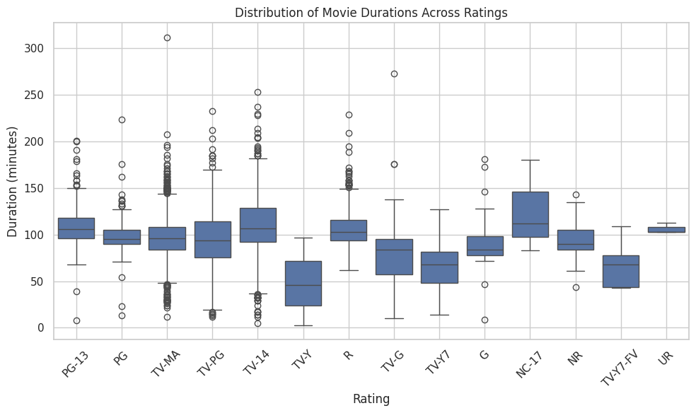

```python
import pandas as pd
import seaborn as sns
import matplotlib.pyplot as plt

df = pd.read_csv('netflix_titles.csv')

df.dropna(subset=['duration', 'rating'], inplace=True)

df_movies = df[df['type'] == 'Movie']

df_movies['duration'] = df_movies['duration'].str.replace(' min', '').astype(int)

rating_order = df_movies['rating'].unique()
1
plt.figure(figsize=(10, 6))
sns.boxplot(x='rating', y='duration', data=df_movies, order=rating_order)
plt.title('Distribution of Movie Durations Across Ratings')
plt.xlabel('Rating')
plt.ylabel('Duration (minutes)')
plt.xticks(rotation=45)
plt.grid(True)
plt.tight_layout()
plt.show()
```

As we can see there is a relationship between the type of movies and the rating of movies. Movies for younger children are very short compared to other movies, probably because the plot is not that intricate. Movies for people aged above 17 had the highest upper quartile and mean. this probably means movies have intricate plots or character arcs that require a longer duration to unfold properly. Overall, while there may be some correlation between movie duration and rating, it's essential to consider the context of each film since the box plot shows there are an immense number of outliers.

### (IV) Primary analysis.

The exploration of the Netflix dataset has led us to choose classification and Regression as the primary machine learning technique. We will apply machine the machine learning algorithm for the two situations below :

1. to predict whether a Netflix title is a movie or a TV show based on its features such as rating, duration, release year, and listed genres.
2. correlation between the genres of Netflix titles and their average ratings.

## Case 1

Our objective is to predict whether a given title on Netflix is a movie or a TV show. This task inherently involves categorizing the titles into two distinct classes based on certain features like rating, duration, release year, and genre. Classification is the ideal technique for such tasks where the goal is to assign labels or categories to data points.

The dataset we're working with contains a mix of numerical and categorical features. Numerical features include attributes like duration and release year, while categorical features include rating, genres, and Comedy. Classification algorithms, like SVM, are well-suited for handling such data types, making them appropriate for our analysis.

The SVM classifier is chosen for its effectiveness in handling high-dimensional data and complex decision boundaries. SVMs excel at finding the optimal hyperplane to separate data points into different classes while maximizing the margin between them. This ability is important for our task, as we aim to accurately distinguish between movies and TV shows based on multiple features.

We preprocess the dataset by encoding categorical features and scaling numerical features to ensure uniformity and enhance model performance. It then splits the data into training and testing sets, with 80% used for training the SVM classifier and 20% for evaluating its performance.

The evaluation metrics used, such as accuracy and the classification report, provide insights into how well the SVM classifier is performing in terms of correctly predicting the type of Netflix title (movie or TV show).

```python
import pandas as pd
import matplotlib.pyplot as plt
import seaborn as sns
from sklearn.model_selection import train_test_split
from sklearn.preprocessing import LabelEncoder, StandardScaler
from sklearn.svm import SVC
from sklearn.metrics import accuracy_score, classification_report, confusion_matrix


features = ['rating', 'duration', 'release_year', 'listed_in']
X = netflix_data[features]
y = netflix_data['type']

label_encoders = {}
for feature in ['rating', 'listed_in']:
    label_encoders[feature] = LabelEncoder()
    X[feature] = label_encoders[feature].fit_transform(X[feature])

X['duration'] = X['duration'].apply(lambda x: int(x.split(' ')[0]) if 'Season' in x else int(x.split(' ')[0]) * 12)

X_train, X_test, y_train, y_test = train_test_split(X, y, test_size=0.2, random_state=42)

scaler = StandardScaler()
X_train[['duration', 'release_year']] = scaler.fit_transform(X_train[['duration', 'release_year']])
X_test[['duration', 'release_year']] = scaler.transform(X_test[['duration', 'release_year']])

svm_classifier = SVC(kernel='rbf', random_state=42)
svm_classifier.fit(X_train, y_train)

y_pred = svm_classifier.predict(X_test)

accuracy = accuracy_score(y_test, y_pred)
print("Accuracy:", accuracy)
print("Classification Report:")
print(classification_report(y_test, y_pred))
```

```
Accuracy: 0.8179749715585893
Classification Report:
              precision    recall  f1-score   support

       Movie       0.84      0.92      0.88      1227
     TV Show       0.76      0.59      0.66       531

    accuracy                           0.82      1758
   macro avg       0.80      0.75      0.77      1758
weighted avg       0.81      0.82      0.81      1758
```

## Case 2

From the below model we are trying to find correlation between the genres of Netflix titles and their average ratings. By analyzing this correlation, we can gain insights into viewers' preferences and tendencies regarding different genres of content available on the platform.

We are choosing the regression technique because our primary objective is to predict numerical values, specifically movie ratings, based on certain features like genres. Regression models can analyze the relationship between independent variables (genres) and a continuous dependent variable (ratings), allowing us to make predictions about movie ratings. We will use linear regression to predict movie ratings based on genres. Linear regression is a simple and effective model for understanding the linear relationship between features and the target variable. By fitting a line to the data points, linear regression can estimate the relationship between genres and ratings.

```python
from sklearn.preprocessing import LabelEncoder


label_encoder = LabelEncoder()
encoded_genres = label_encoder.fit_transform(df['listed_in'])

df['encoded_genres'] = encoded_genres


import pandas as pd
from sklearn.model_selection import train_test_split
from sklearn.preprocessing import LabelEncoder
from sklearn.linear_model import LinearRegression
from sklearn.metrics import mean_squared_error

label_encoder = LabelEncoder()
df['encoded_rating'] = label_encoder.fit_transform(df['rating'])

X = df[['encoded_genres']]
y = df['encoded_rating']

X_train, X_test, y_train, y_test = train_test_split(X, y, test_size=0.2, random_state=42)

linear_regression = LinearRegression()
linear_regression.fit(X_train, y_train)


y_pred = linear_regression.predict(X_test)

mse = mean_squared_error(y_test, y_pred)
print("Mean Squared Error:", mse)
r_squared = linear_regression.score(X_test, y_test)
print("R-squared:", r_squared)
```

```
Mean Squared Error: 3.4656713182640737
R-squared: 0.051748236064923736
```

The obtained mean squared error (MSE) of approximately 3.47 indicates a moderate level of prediction error in the linear regression model for movie ratings based on genres. Additionally, the low R-squared value of around 0.05 suggests that only a small proportion of the variance in movie ratings is explained by the genres included in the model. This indicates that the linear relationship between genres and movie ratings might not be strong or adequately captured by the model. This tells us that the model does not fit the data well.

(**V**) Visualization.

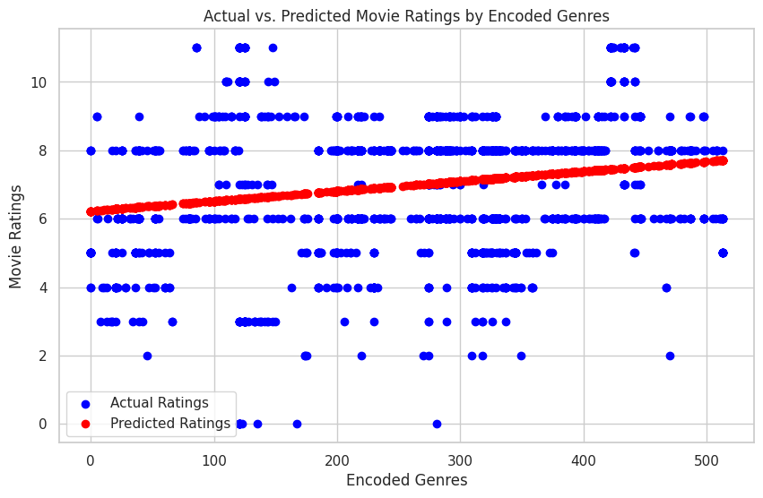

```python
import matplotlib.pyplot as plt


plt.figure(figsize=(10, 6))
plt.scatter(X_test['encoded_genres'], y_test, color='blue', label='Actual Ratings')
plt.scatter(X_test['encoded_genres'], y_pred, color='red', label='Predicted Ratings')

# Labels and Title
plt.xlabel('Encoded Genres')
plt.ylabel('Movie Ratings')
plt.title('Actual vs. Predicted Movie Ratings by Encoded Genres')


plt.legend()


plt.show()
```

It seems like there's a lot of difference between the data points and what the model predicted. The actual data points are far away from the predicted solid line shown in red. This suggests that the model might not be doing a good job of guessing the right outcomes based on the data. We might need to look into the model more and maybe change some things to make it better at predicting.

[figure not shown]

```python
import matplotlib.pyplot as plt
import seaborn as sns
from sklearn.metrics import confusion_matrix, ConfusionMatrixDisplay


cm = confusion_matrix(y_test, y_pred)


plt.figure(figsize=(8, 6))
sns.heatmap(cm, annot=True, cmap='Blues', fmt='g', cbar=False)
plt.title('Confusion Matrix')
plt.xlabel('Predicted')
plt.ylabel('Actual')
plt.xticks(ticks=[0.5, 1.5], labels=['Movie', 'TV Show'])
plt.yticks(ticks=[0.5, 1.5], labels=['Movie', 'TV Show'])
plt.show()
```

## (VI)Insights and Conclusions

Through this project, we explored a comprehensive dataset of Netflix titles, employing a variety of data analysis techniques to uncover patterns and trends in the streaming content provided by Netflix.

Key Insights We're using a method called SVM to do this, which is good for handling different kinds of information, like how long the title is or when it was released. We're splitting the information we have into two groups: one to teach the SVM how to make guesses, and another to see if it's making good guesses. Our guesses are about 82% correct, which is pretty good. We found out that the SVM is better at guessing movies than TV shows, and we have some ideas on how to make it better at guessing TV shows too. So, even if you didn't know much before, you should have a good idea of what's going on now. And if you already knew a bit about this stuff, you might have learned a bit more.